# Defining a model in lgpr

Juho Timonen

2020-10-12

```r
require(lgpr)
# Loading required package: lgpr
# This is lgpr (version 1.0.3).
require(ggplot2)
# Loading required package: ggplot2
require(nlme)
# Loading required package: nlme
```

## Introduction

The class `lgpmodel` represents an additive Gaussian process model. Such models can be created in `lgpr` using the function `create_model()`, and they can be fit by calling `sample_model()`. The easiest way, however, is probably to use the `lgp()` function which wraps both `create_model()` and `sample_model()` and has all the same arguments. The complete information about these arguments is in the documentation, but here we review the most common ones, i.e. `formula`, `data` and `prior`.

In this tutorial we focus on defining a model with `create_model()`, and the same syntax applies to `lgp()`.

## Specifying data

The `data` argument to `lgp()` or `create_model()` should be a `data.frame` where continuous variables have a numeric type and categorical variables are factors.

Here we use the `Orthodont` data set from the `nlme` package.

```r
dat <- data.frame(Orthodont)
dat$Sex <- as.factor(as.character(dat$Sex))
dat$Subject <- as.factor(as.character(dat$Subject))
str(dat)
# 'data.frame': 108 obs. of  4 variables:
#  $ distance: num  26 25 29 31 21.5 22.5 23 26.5 23 22.5 ...
#  $ age     : num  8 10 12 14 8 10 12 14 8 10 ...
#  $ Subject : Factor w/ 27 levels "F01","F02","F03",..: 12 12 12 12 13 13 13 13 14 14 ...
#  $ Sex     : Factor w/ 2 levels "Female","Male": 2 2 2 2 2 2 2 2 2 2 ...
```

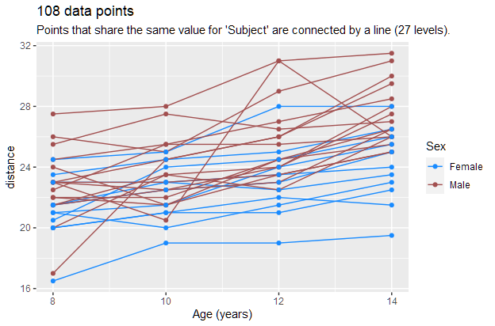

```r
plot_data(dat, x_name = "age", y_name = "distance", group_by = "Subject",
          color_by = "Sex") + xlab('Age (years)')
```

## Specifying the model formula

The `formula` argument to `lgp()` or `create_model()` specifies the response variable, model components and covariates.

### A) Common formula syntax

Here we create a model with the continuous variable `age` and categorical variables `Subject` and `Sex` as predictors for `distance`.

```r
model <- create_model(distance ~ age + age|Sex + age|Subject, dat, verbose = FALSE)
print(model)
# An object of class lgpmodel. See ?lgpmodel for more info.
# Formula: distance ~ gp(age) + gp(age) * zs(Sex) + gp(age) * zs(Subject)
# Likelihood: gaussian
# Data: 108 observations, 4  variables
#
#             Component type ker het ns vm unc cat cont
# 1             gp(age)    1   0   0  0  0   0   0    1
# 2     gp(age)*zs(Sex)    2   0   0  0  0   0   1    1
# 3 gp(age)*zs(Subject)    2   0   0  0  0   0   2    1
#
#   Variable #Missing
# 1      age        0
#
#    Factor #Levels       Values
# 1     Sex       2 Female, Male
# 2 Subject      27          ...
#
#   Parameter   Bounds                         Prior
# 1  alpha[1] [0, Inf)      alpha[1] ~ student-t(20)
# 2  alpha[2] [0, Inf)      alpha[2] ~ student-t(20)
# 3  alpha[3] [0, Inf)      alpha[3] ~ student-t(20)
# 4    ell[1] [0, Inf)      ell[1] ~ log-normal(0,1)
# 5    ell[2] [0, Inf)      ell[2] ~ log-normal(0,1)
# 6    ell[3] [0, Inf)      ell[3] ~ log-normal(0,1)
# 7  sigma[1] [0, Inf) (sigma[1])^2 ~ inv-gamma(2,1)
```

The formula `distance ~ age + age|Sex + age|Subject` has the same format as for example in the `lme4` package, which uses linear mixed effect models. It creates a model with three components:

1. the shared effect of age
2. the sex-specific deviation from the shared age effect
3. the subject-specific deviation from the shared age effect

If we wanted effects 2. and 3. to not depend on age, we could write the formula as just `distance ~ age + Sex + Subject`.

### B) Advanced formula syntax

The above formula was actually automatically converted to the more specific format `distance ~ gp(age) + gp(age)*zs(Sex) + gp(age)*zs(Subject)`. The `lgpr` package has this advanced syntax, because the common formula syntax of R is not expressive enough for all kinds of components that our models can have. Formulae specified using the advanced syntax consist of terms which can combine the following expressions through addition and multiplication:

- `gp(x)` specifies a standard GP with exponentiated quadratic kernel
- `gp_ns(x)` specifies a GP with a nonstationary kernel
- `gp_vm(x)` specifies a GP with a variance-masked kernel
- `zs(z)` specifies a GP with zero-sum kernel
- `categ(z)` specifies a GP with categorical kernel
- terms multiplied by `unc(z)` have uncertainty in their continuous covariate, so that each level of `z` introduces one uncertainty parameter
- terms multiplied by `het(z)` are have heterogeneity in the effect of their continuous covariate, so that each level of `z` introduces one level-specific magnitude parameter

Above, `x` was used to denote any continuous and `z` any categorical variable. Each term can contain at most one continuous variable. Components which contain `gp(x)`, `gp_ns(x)`, or `gp_vm(x)` and have `NaN` or `NA` in the data of `x` are automatically multiplied by a mask for the missing values.

## Specifying parameter priors

The `prior` argument to `lgp()` or `create_model()` specifies the prior distribution for kernel hyperparameters and other model parameters. In above model, we did not speficy `prior`, so default priors were used. Custom priors can be given as a named list, like here:

```r
prior <- list(
  alpha = normal(mu = 0, sigma = 1), # gaussian for magnitudes <alpha>
  ell = igam(shape = 5, scale = 5) # inverse gamma for lengthscales <ell>
)

model2 <- create_model(formula = distance ~ age + age|Sex + age|Subject,
                       data = dat,
                       prior = prior)
param_summary(model2)
#   Parameter   Bounds                         Prior
# 1  alpha[1] [0, Inf)        alpha[1] ~ normal(0,1)
# 2  alpha[2] [0, Inf)        alpha[2] ~ normal(0,1)
# 3  alpha[3] [0, Inf)        alpha[3] ~ normal(0,1)
# 4    ell[1] [0, Inf)       ell[1] ~ inv-gamma(5,5)
# 5    ell[2] [0, Inf)       ell[2] ~ inv-gamma(5,5)
# 6    ell[3] [0, Inf)       ell[3] ~ inv-gamma(5,5)
# 7  sigma[1] [0, Inf) (sigma[1])^2 ~ inv-gamma(2,1)
```

Specifying the `prior` argument as a named list gave the same prior for all parameters matching that name. If we wanted separate priors for example for each lengthscale parameter, we could specify `ell` itself as a list with length 3.

## When to not use default priors

It is not recommended to use default priors blindly. Rather, priors should be specified according to the knowledge about the problem at hand, as in any Bayesian analysis. In `lgpr` this is especially important when

- Using a non-Gaussian likelihood or otherwise setting `sample_f = TRUE`. In this case the response variable is not normalized, so the scale on which the data varies must be taken into account when defining priors of the signal magnitude parameters and possible noise parameters (`sigma`, `phi`, `gamma`). Also it should be checked if `c_hat` is set in a sensible way.
- Using a model that contains a `gp_ns(x)` or `gp_vm(x)` expression in its formula. In this case the corresponding covariate `x` is not normalized, and the prior for the input warping steepness parameter `wrp` must be set according to the expected width of the window in which the nonstationary effect of `x` occurs. By default, the width of this window is about 36, which has been set assuming that the unit of `x` is months.